# To Determine the role of Region, Gender and Age in contracting COVID - 19

Shivam Hrjai

05/06/2020

## Question Statement

The following program demonstrates the implementation of data analysis on a Covid-19 dataset. The analysis has been done to understand if the Corona Virus or COVID - 19 depends on the age, region or the Gender of the person. This program also focuses on topography, thereby generating country specific results.

```r
library(readr)
library(tidyverse)
library(dplyr)
library(lubridate)
```

```r
library(maps)
library(ggplot2)
library(GGally)
```

## Loading the dataset in

The dataset was loaded in the program by read_csv() present in tidyverse. The working directory was set before-hand

```r
data <- read_csv("Covid_dataset2020.csv")
```

## ANOMALAY ELIMINATION

As the first part suggests this dataset is not tidy. Several anomalays were detected such as -

```
1. All of the columns which were supposed to contain dates, were present in different formats. They were identified and taken care of as follows -
```

```r
  data$reporting_date <- parse_date_time(data$reporting_date, orders = c("mdy", "dmy"))
data$symptom_onset <- parse_date_time(data$symptom_onset, orders = c("mdy", "dmy"))
data$visit_date_hosp <- parse_date_time(data$visit_date_hosp, orders = c("mdy", "dmy"))
data$exposure_startdate <- parse_date_time(data$exposure_startdate, orders = c("mdy", "dmy"))

data$exposure_enddate <- parse_date_time(data$exposure_enddate, orders = c("mdy", "dmy"))

data$recovered <- parse_date_time(data$recovered, orders = c("mdy", "dmy"))
```

```
## Warning: 379 failed to parse.
```

```r
data$death <- parse_date_time(data$death, orders = c("mdy", "dmy"))
```

```
## Warning: 416 failed to parse.
```

NOTE - All of these warnings above are simply NA values, which couldn’t be parsed.

2. The column international traveller had one column named “W”, which had to be assigned NA

```r
tempIntl <- data$intl_traveler
tempIntl[4] <- NA
data$intl_traveler <- tempIntl
```

3. The columns visiting Wuhan and lives in Wuhan had “Yes” and “No” values, which had to be changed to 1 and 0 respectively.

```r
data$visiting_Wuhan[data$visiting_Wuhan == "No"] = 0
data$visiting_Wuhan[data$visiting_Wuhan == "Yes"] = 1
data$lives_in_Wuhan[data$lives_in_Wuhan == "No"] = 0
data$lives_in_Wuhan[data$lives_in_Wuhan == "Yes"] = 1
```

Our dataset finally is clean, and we can now view it -

```r
View(data)
```

We can export the dataset now by the following command -

```r
write_csv(data, "tidydataset_2017CSC1018.csv")
```

## INITIAL ANALYSIS OF OUR DATA

```r
data <- read_csv( "tidydataset_2017CSC1018.csv")
```

To even begin thinking about manipulating the data, we first see it in the simplest EDA known to us , the bar-plot

```r
countryData <- data %>% group_by(country) %>% summarise(case_in_country = last(case_in_country))
```

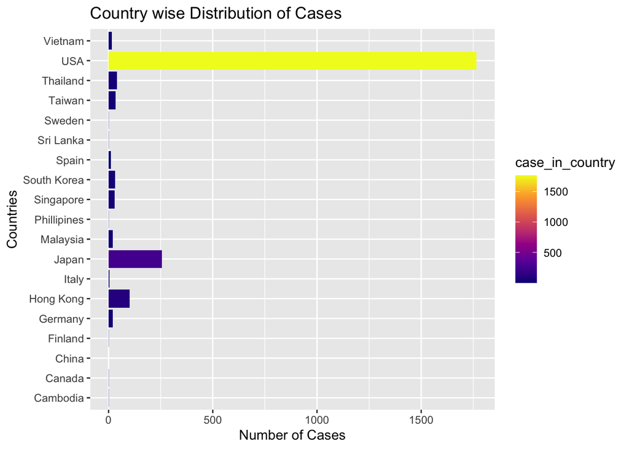

```r
ggplot(countryData, aes(x = country, y =case_in_country)) +
  geom_bar(stat = "identity",aes(fill=case_in_country) ) +
  scale_fill_viridis_c(option = "C") +
  coord_flip() +
  labs(title = "Country wise Distribution of Cases",
       y="Number of Cases",x="Countries")
```

The co-ordinates were flipped here, to get a more readable view.

Now, upon first observation, it is clearly visible that the USA has the most number of Corona cases, and no other country is remotely close.

Since the virus originated in China (general information, not given in the dataset), can we say with certainnity that the origin of the virus has little or no effect on the speed with which the virus will spread?

Looking at these countries with virus cases geographically might help.

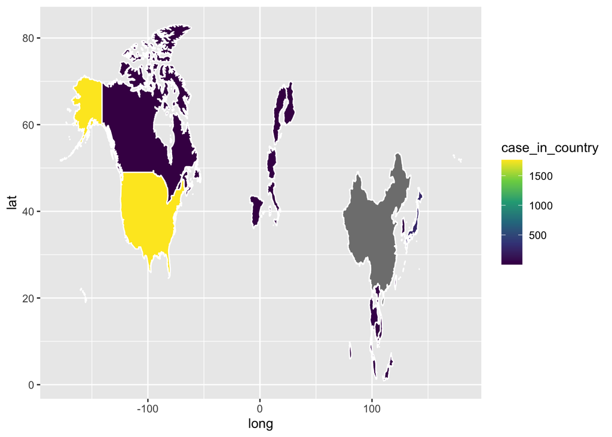

```r
world_map <- map_data("world")
world_map$region[which(world_map$subregion == "Hong Kong")] <- "Hong Kong"
world_map$region[which(world_map$subregion == "Finland")] <- "Finland"
world_map$region[which(world_map$subregion == "Phillipines")] <- "Phillipines"


countryData <- countryData %>% rename(region = country)

dest_map <- left_join(countryData, world_map)
ggplot(dest_map, aes(long, lat, group = group), xlim(0,100))+
  geom_polygon(aes(fill = case_in_country), color = "white")+
  scale_fill_viridis_c(option = "D")
```

We see here, that the USA is around the -100 longitude, and no country(except Cananda) is near it. Even so, Canada has far less cases, which might be due to the international ban imposed

Thus, it is concluded that the origin of the virus has very little effect on its spread

(NOTE - Other factors asto why the spread in USA might be so large are discussed below).

## A CLOSER LOOK AT THE GENDERS

Now, our aim is to determine if a single gender is more susceptible to this virus, and is that is so, is that trend prevelant regionally.

For this, first we plot the bar graph of both the genders.

```r
  genderData <- data %>% group_by(gender) %>% summarise(total_affected=n())
```

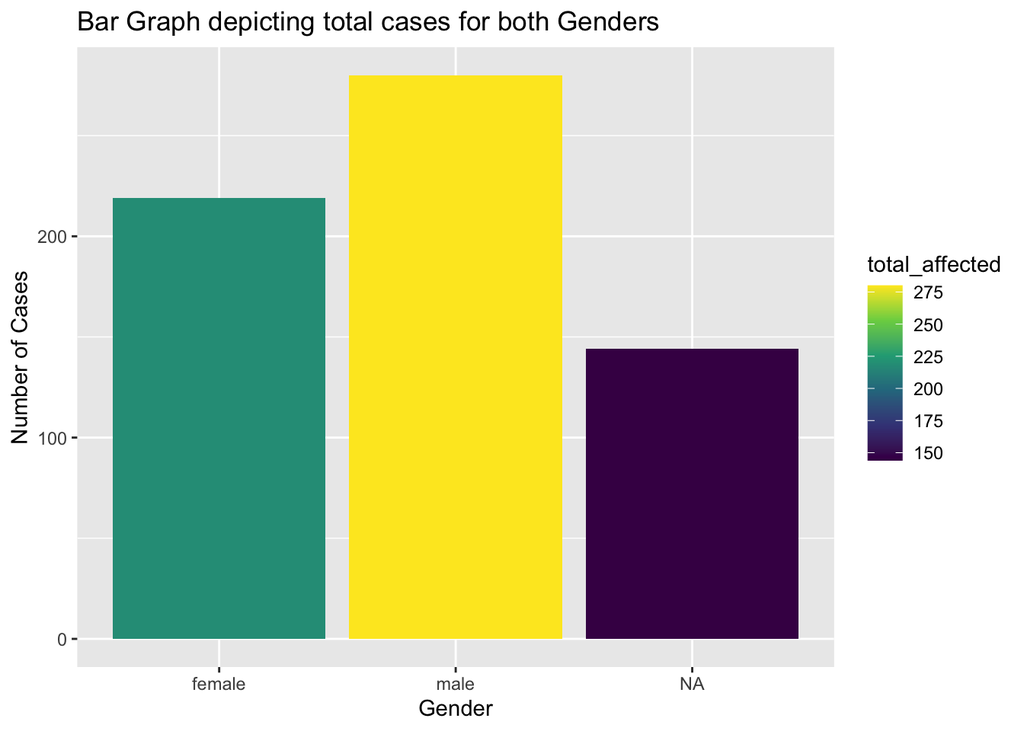

```r
  ggplot(genderData, aes(gender, total_affected)) +
  geom_bar(stat = "identity", aes(fill = total_affected)) +
  scale_fill_viridis_c(option = "D") +
  labs(title = "Bar Graph depicting total cases for both Genders",
       y="Number of Cases",x="Gender")
```

From the above bar graph we can clearly see that men are more affected by this virus than women, almost a third more It is also interesting to note that there are alot of NA values, but however, they are less than a third so we can easily draw meaningfull conclusions.

It is very important that we make a function to calculate the mode of columns, as determining the mode will help us understand if a certain sect of population is targetted.

```r
  getmode <- function(v) {
    uniqv <- unique(v)
    uniqv[which.max(tabulate(match(v, uniqv)))]
  }
```

Now let us see a density plot of the age of people affected, organised by country

```r
modeData <- select(data, country, age) %>% filter(!is.na(age)) %>% group_by(country) %>% summarise(mode_age = getmode(age))
```

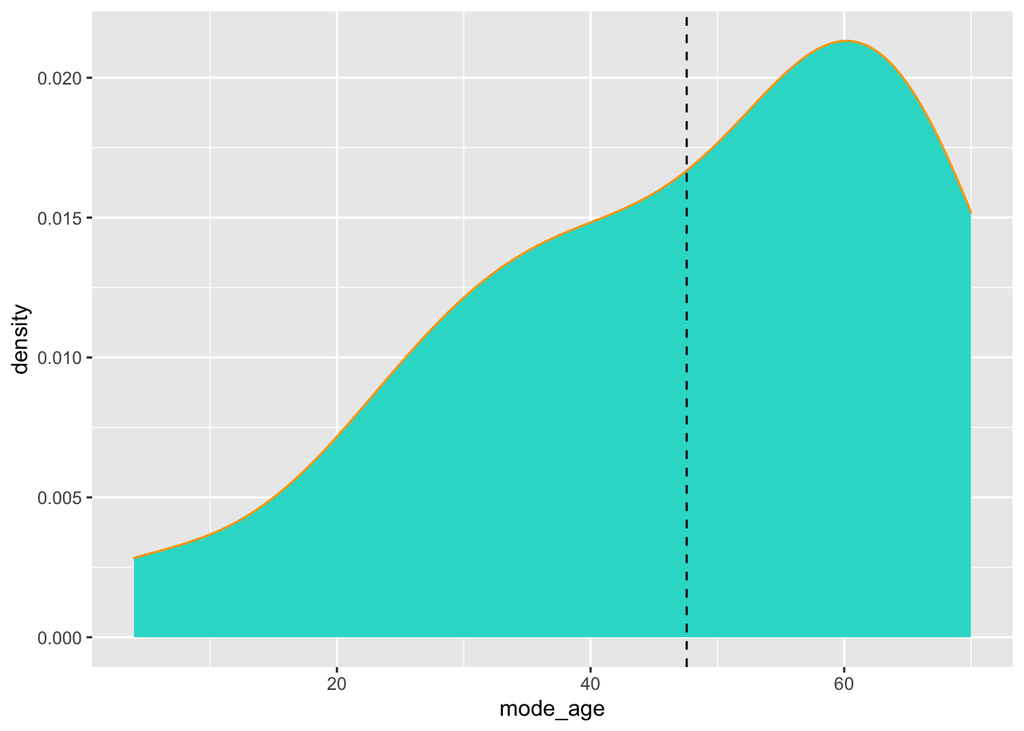

```r
  ggplot(modeData, aes(x = mode_age)) +
    geom_density(color="orange1", fill="#2ADBCF") +
    geom_vline(aes(xintercept = mean(mode_age)), linetype = "dashed")
```

Now we must find the mean of the variable mode_age, since finding the mode of mode_age will do us no good. We need to determine the average of the most occuring age value of each country.

```r
ungenderedMean <- mean(modeData$mode_age)
ungenderedMean
```

```
## [1] 47.57895
```

Here is a boxplot of the same above -

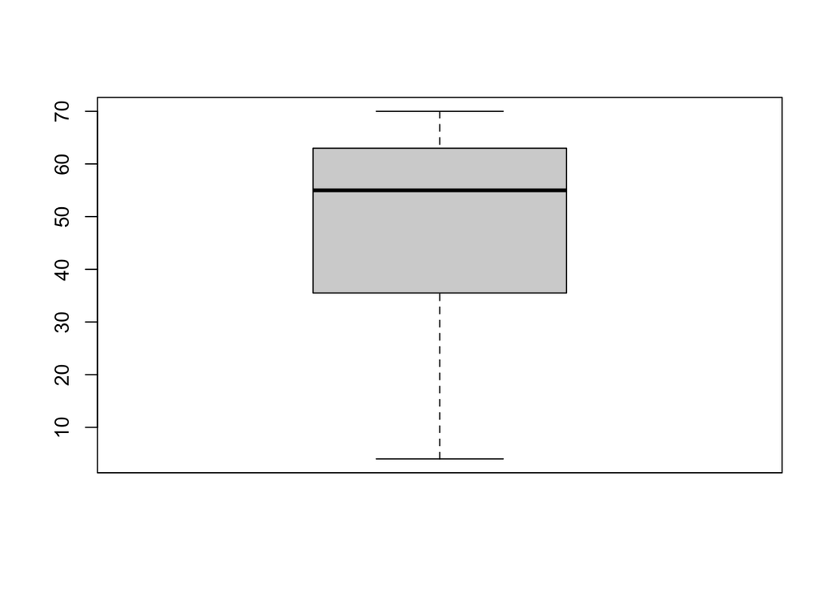

```r
boxplot(modeData$mode_age)
```

## FEMALE COVID DATA

However things take an interesting toll when we calculate the same for all of the females, all over the different countries given to us.

```r
gendered_mode_data <- select(data, country, age, gender) %>% filter(!is.na(age), !is.na(gender)) %>% group_by(country, gender) %>% summarise(mode_age = getmode(age))
```

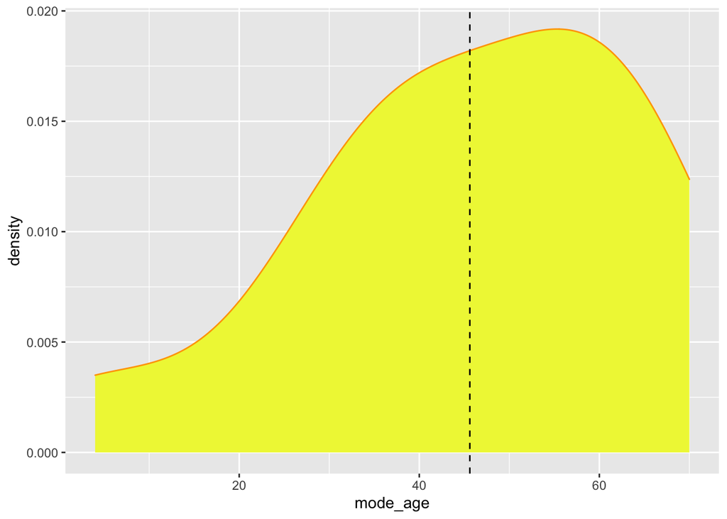

```r
female_mode_data <- select(gendered_mode_data, country, mode_age, gender) %>% filter(gender == "female")
ggplot(female_mode_data, aes(x = mode_age)) +
  geom_density(color="orange1", fill="#EFF542") +
  geom_vline(aes(xintercept = mean(mode_age)), linetype = "dashed")
```

```r
femaleMean <- mean(female_mode_data$mode_age)
```

The average most commonly occuring age value is -

```r
femaleMean
```

```
## [1] 45.61538
```

We’ll comment on this later.

Here is the boxplot -

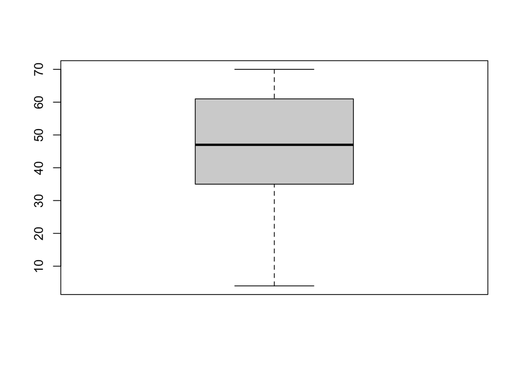

```r
boxplot(female_mode_data$mode_age)
```

## MALE COVID DATA

Finally, we will plot the density of the mode age of all the men from all the countries.

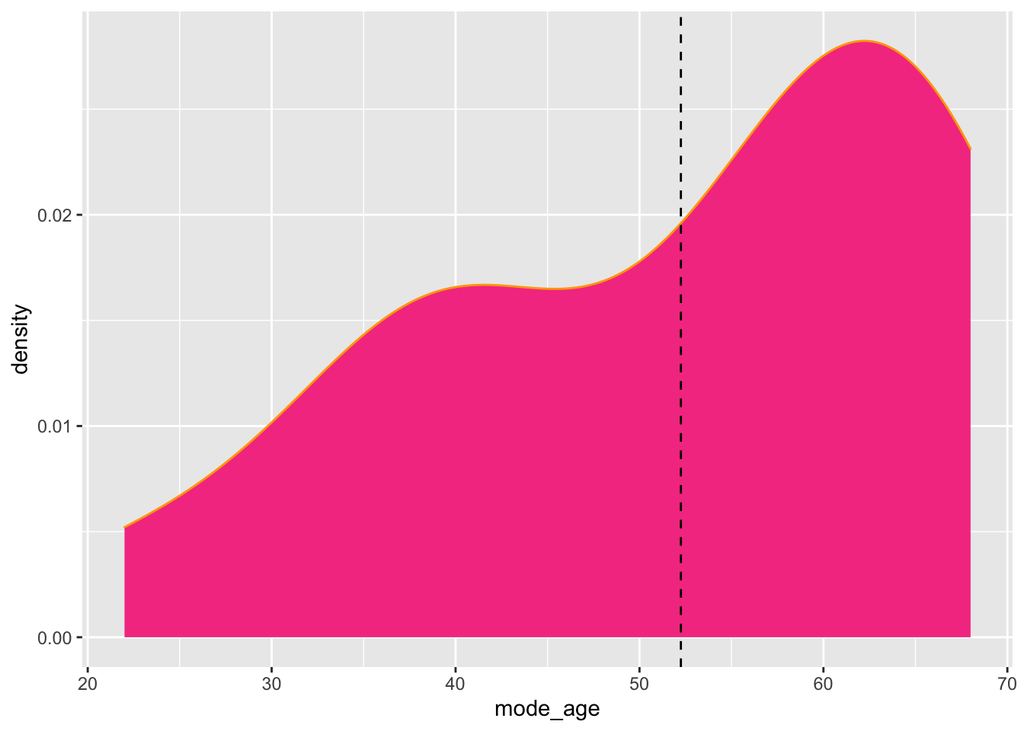

```r
male_mode_data <- select(gendered_mode_data, country, mode_age, gender) %>% filter(gender == "male")

ggplot(male_mode_data, aes(x = mode_age)) +
  geom_density(color="orange1", fill="#F54290") +
  geom_vline(aes(xintercept = mean(mode_age)), linetype = "dashed")
```

```r
maleMean <- mean(male_mode_data$mode_age)
```

It is clearly visible that although the highest frequency is of age 60, there is an usual jump at the age of 40, which was not observed in females. Thus we can also conclude here that men roughly betwenn 35-45 are at a slightly more rish than their subsequent.

Agani, the mean of the mode ages is -

```r
maleMean
```

```
## [1] 52.25
```

Here is the boxplot of the same -

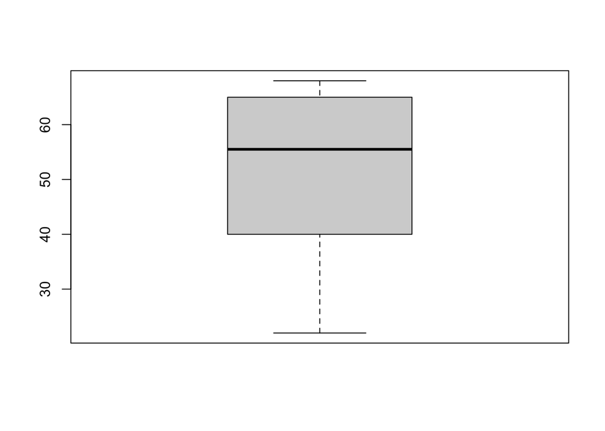

```r
boxplot(male_mode_data$mode_age)
```

It is clear that most of the cases occur between the ages of 40 and 60

## WHAT DOES ALL OF THIS MEAN - My final Thoughts

The mean of men came out to be 52, whilst that of women was 45. It is clear that an abnormality exist, however, relatively a difference of 7 years is not much considering if a person has already been alive for 45+ years.

7 year though, are still pretty close to a decade, and despite of all the relevancies, we conclude that Men are slightly more at risk than women when it comes to contracting the Corona virus

## VARIABLES AND THEIR CORRELATION

I first applied the following built in function to some numeric columns to check wether a correlation existed -

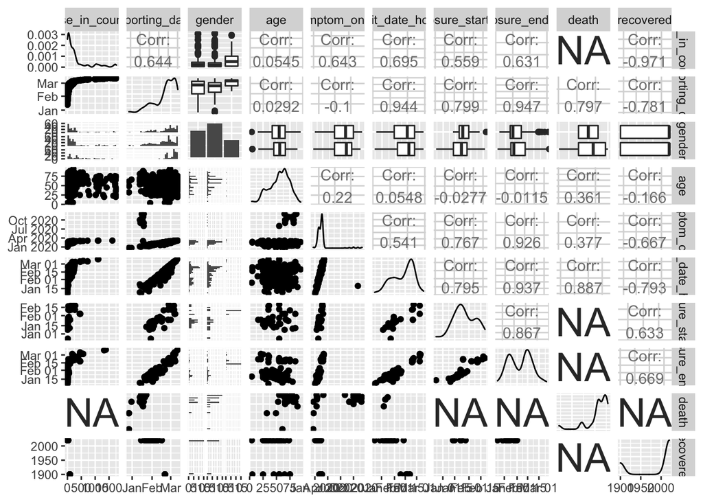

```r
ggpairs(data=data, columns=c(3,4,6,7,8,9,12,13,16,17))
```

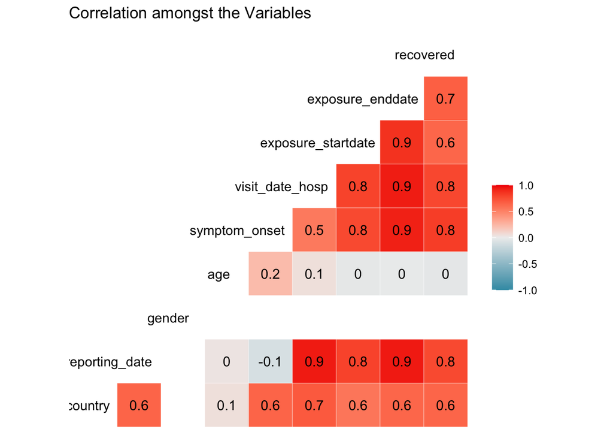

```r
corr.data=lapply(data[,c(3,4,6,7,8,9,12,13,17)],as.integer)
ggcorr(corr.data,palette = "RdBu", label = TRUE,hjust = 0.85)+ ggtitle("Correlation amongst the Variables")
```

These were my final results for correlation.

A strong correlation between system onset and exposure startdate exists

*** ___ ***